# Final Project

## Variation of Hate Crimes Across the U.S.

We also wanted to see if the frequency of hate crime varied substantially across the U.S. We didn’t want to simply plot the number of hate crimes that occured in an area because states with larger populations to begin with would be expected to have a higher number of hate crimes. Therefore, we merged our FBI hate crime data with population data of cities from the 2010 U.S. Census. For each state, we took the number of hate crimes from all the cities in that state divided by the sum of the population of those cities, giving us the rate of hate crimes per person. Mapping the results onto a map of the U.S. (with lighter colors indicating higher rates of hate crimes) shows us some patterns among the states.

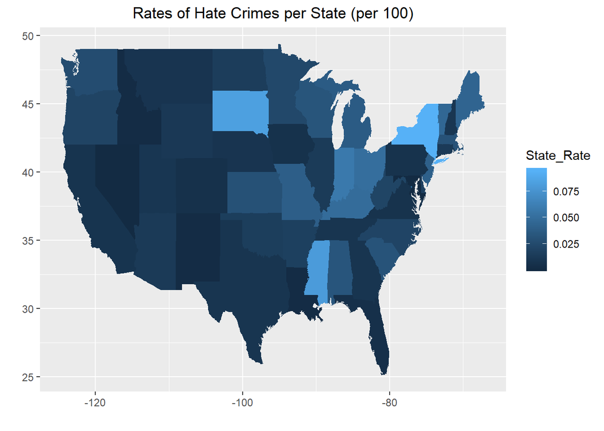

The states that stand out in particular are South Dakota, New York, and Mississippi, which are shaded with the lightest colors (most hate crimes given the population). Initially, before starting this project, we had hypothesized that states in the South would have the worst rates of hate crime (especially given the historical tendencies).

Unfortunately, the population data from the Census was not merged perfectly with the FBI crime data, and we wanted to make sure that we had as much available data on hate crime in cities as possible. Luckily, the hate crime dataset also classifies cities/counties by population. Therefore, by only comparing the total number of hate crimes for cities of a certain size (we tested it for cities with a population from 250,000 to 499,999) we would ensure that the overall populations of those cities are comparable. Surprisingly, for cities (with a population from 250,000 to 499,999), Southern cities actually had a lower mean for the total number of hate crimes than the rest of the U.S.

From the map, the Midwest also seemed to have relatively higher rates of hate crimes, so we decided to compare Southern cities directly with Northeastern cities. Selecting a subset of the data that only contained cities for the Northeast and for the South, we ran a permutation test. The p-value was above 0.5, showing that surprisingly, the South did not actually have statistically higher hate crime rates than the Northeast.

As we mentioned previously, the Midwestern states seemed to have relatively higher rates of hate crime, so we did another permutation test comparing Midwestern cities with cities in the other regions (Northeast, South, West) of the same population size. The p-value was about 0.008, showing that cities in the Midwest do have statistically higher hate crime rates. A chi-square test returns a similar p-value.

```r
chi
```

```
## [1] 5.634124
```

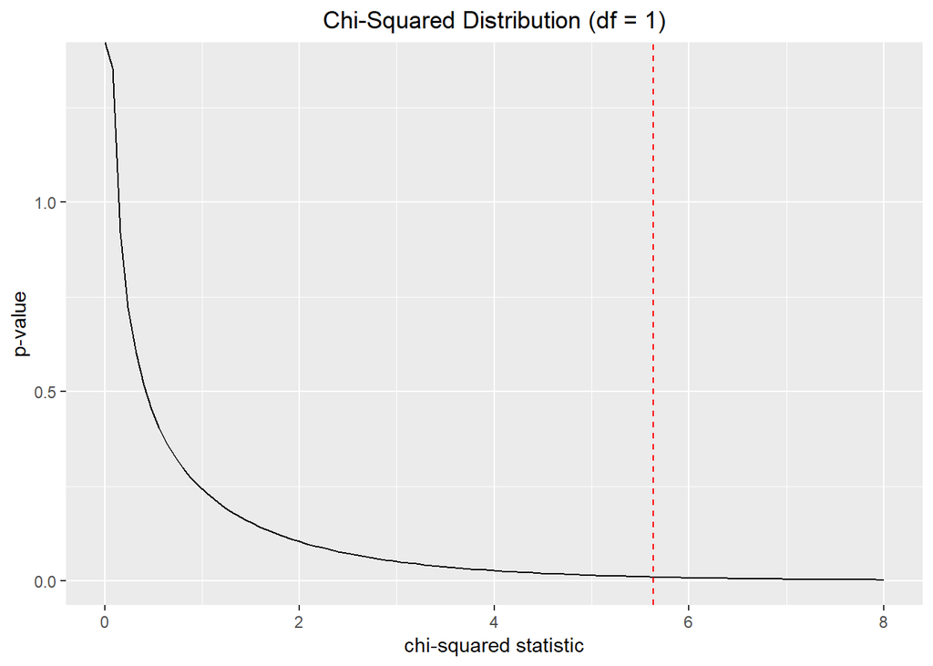

We were also curious to see the breakdown of the different hate crime biases (anti-Black, anti-Catholic, etc.) across the U.S. One breakdown that was interesting was mapping the anti-American Indian or Alaska Native hate crime rates.

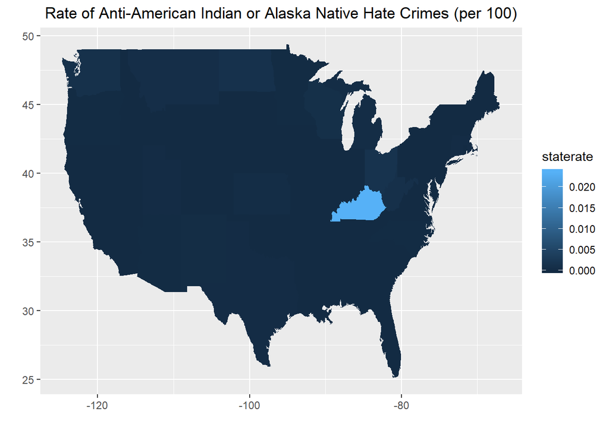

While most states had generally low rates of anti-American Indian crime rates (presumably also because of the relatively low percentage of American Indian populations in the U.S.), Kentucky stood out as having much higher rates. To test whether these higher rates were actually significant, a permutation test was conducted. We controlled for population size in the cities (by only comparing cities with a population from 250,000 to 499,999), and the permutation test return a p-value that was about 10^(-4), demonstrating a statistically significant difference between Kentucky and the other states.

## Non-MSA vs MSA Counties

We wanted to compare whether the actual composition or qualities of an area could impact the number of hate crimes as well. Therefore, we decided to compare non-MSA vs. MSA counties. MSA stands for Micropolitan/Metropolitan Statistical Area, which are areas that tend to have areas with very dense populations and a “high degree of social and economic integration” with the surrounding areas (Federal Register). We wanted the population of the counties and the geographical layout of these non-MSA and MSA counties to be comparable as well to ensure that any hate crime differences found between them was truly due to their economic qualities or population densities instead of other outside factors. Therefore, we looked at non-MSA and MSA counties with populations from 25,000 to 99,999. Calculating the fraction of non-MSA and MSA counties in the Northeast, South, West, and Midwest shows that the distribution of non-MSA and MSA counties in the different regions are similar as well. A permutation test was conducted for the total number of hate crimes for MSA and non-MSA counties. The p-value was about 0.049, which demonstrates that MSA counties have statistically higher levels of hate crime than non-MSA counties. A chi-square test confirms that the result is indeed statistically significant. Although the non-MSA and MSA counties compared in our analysis have similar populations, the fact that MSA counties have areas with higher population densities perhaps allow for more interactions between people and for more hate crimes to happen.

```r
msachi
```

```
## [1] 7.269622
```

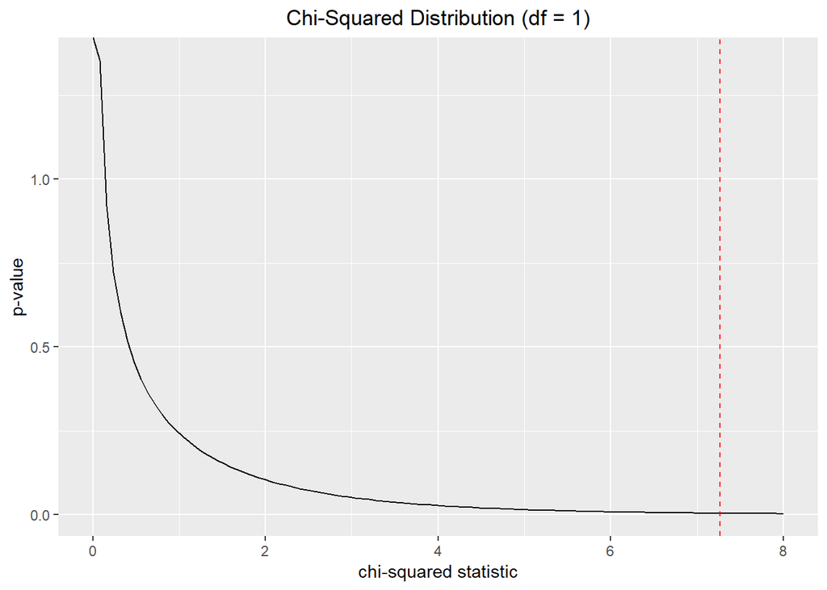

### Sources

https://www.fbi.gov/services/cjis/ucr/hate-crime

https://www.census.gov/data/tables/2017/demo/popest/total-cities-and-towns.html

https://www.govinfo.gov/content/pkg/FR-2010-06-28/pdf/2010-15605.pdf

`Analysis performed by Jenny Gu and Yijiang Zhao`